# Exploratory Data Analysis for ML CLassification Problem

Author: André Rizzo  
January 2021

#### **Clean all stored variables**

```r
rm(list = ls())
```

#### **Set Working directory**

```r
knitr::opts_knit$set(root.dir = 'C:/temp/Iris')
```

#### **Load all required libraries**

```r
# Load libraries
library(readr)
library(Hmisc) #For describe()
```

```r
library(pastecs) #For stat.desc()
library(car) #For qqPlot
library(PerformanceAnalytics)
library(caret) #For BoxCoxTrans and filterVarImp
library(e1071) #For BoxCoxTrans
library(normtest) #For ad.test and others
library(bestNormalize) #For OrderNorm and Yeo-Johnson transformations
library(ggplot2)
library(CORElearn) #For Relief
library(randomForest)
```

#### **Import dataset**

```r
df = read_csv("./data/original/iris.data")
```

#### **Show the very first 10 lines from the dataset**

```r
head(df, n = 10)
```

| 5.1 | 3.5 | 1.4 | 0.2 | Iris-setosa |
| --- | --- | --- | --- | --- |
| 4.9 | 3.0 | 1.4 | 0.2 | Iris-setosa |
| 4.7 | 3.2 | 1.3 | 0.2 | Iris-setosa |
| 4.6 | 3.1 | 1.5 | 0.2 | Iris-setosa |
| 5.0 | 3.6 | 1.4 | 0.2 | Iris-setosa |
| 5.4 | 3.9 | 1.7 | 0.4 | Iris-setosa |
| 4.6 | 3.4 | 1.4 | 0.3 | Iris-setosa |
| 5.0 | 3.4 | 1.5 | 0.2 | Iris-setosa |
| 4.4 | 2.9 | 1.4 | 0.2 | Iris-setosa |
| 4.9 | 3.1 | 1.5 | 0.1 | Iris-setosa |
| 5.4 | 3.7 | 1.5 | 0.2 | Iris-setosa |

**Analysis:**

- It will be necessary to create an header for the dataset.

#### **Create labels**

```r
colnames(df) = c("sepal_length", "sepal_width", "petal_length", "petal_width", "class")
colnames(df)
```

```
## [1] "sepal_length" "sepal_width"  "petal_length" "petal_width"  "class"
```

#### **Check the first 10 lines again**

```r
head(df, n = 10)
```

| sepal_length | sepal_width | petal_length | petal_width | class |
| --- | --- | --- | --- | --- |
| 4.9 | 3.0 | 1.4 | 0.2 | Iris-setosa |
| 4.7 | 3.2 | 1.3 | 0.2 | Iris-setosa |
| 4.6 | 3.1 | 1.5 | 0.2 | Iris-setosa |
| 5.0 | 3.6 | 1.4 | 0.2 | Iris-setosa |
| 5.4 | 3.9 | 1.7 | 0.4 | Iris-setosa |
| 4.6 | 3.4 | 1.4 | 0.3 | Iris-setosa |
| 5.0 | 3.4 | 1.5 | 0.2 | Iris-setosa |
| 4.4 | 2.9 | 1.4 | 0.2 | Iris-setosa |
| 4.9 | 3.1 | 1.5 | 0.1 | Iris-setosa |
| 5.4 | 3.7 | 1.5 | 0.2 | Iris-setosa |

**Analysis**

- Now the dataframe labels are ok.

#### **Show the very last 10 lines from the dataset**

```r
tail(df, n = 10)
```

| sepal_length | sepal_width | petal_length | petal_width | class |
| --- | --- | --- | --- | --- |
| 6.7 | 3.1 | 5.6 | 2.4 | Iris-virginica |
| 6.9 | 3.1 | 5.1 | 2.3 | Iris-virginica |
| 5.8 | 2.7 | 5.1 | 1.9 | Iris-virginica |
| 6.8 | 3.2 | 5.9 | 2.3 | Iris-virginica |
| 6.7 | 3.3 | 5.7 | 2.5 | Iris-virginica |
| 6.7 | 3.0 | 5.2 | 2.3 | Iris-virginica |
| 6.3 | 2.5 | 5.0 | 1.9 | Iris-virginica |
| 6.5 | 3.0 | 5.2 | 2.0 | Iris-virginica |
| 6.2 | 3.4 | 5.4 | 2.3 | Iris-virginica |
| 5.9 | 3.0 | 5.1 | 1.8 | Iris-virginica |

**Analysis**

- The dataframe end also seems to be ok.

#### **Create auxiliary datasets before performing the data analysis**

```r
df_num = df[,-5]
df_cat = df[,5]
```

**Analysis:**

- *df_num* dataset was created to store only the numerical variables.
- *df_cat* dataset was created to store only the categorical variables.

#### **Check the dataset structure**

##### *Check variables*

```r
str(df_num)
```

```
## tibble [149 x 4] (S3: tbl_df/tbl/data.frame)
##  $ sepal_length: num [1:149] 4.9 4.7 4.6 5 5.4 4.6 5 4.4 4.9 5.4 ...
##  $ sepal_width : num [1:149] 3 3.2 3.1 3.6 3.9 3.4 3.4 2.9 3.1 3.7 ...
##  $ petal_length: num [1:149] 1.4 1.3 1.5 1.4 1.7 1.4 1.5 1.4 1.5 1.5 ...
##  $ petal_width : num [1:149] 0.2 0.2 0.2 0.2 0.4 0.3 0.2 0.2 0.1 0.2 ...
```

```r
str(df_cat)
```

```
## tibble [149 x 1] (S3: tbl_df/tbl/data.frame)
##  $ class: chr [1:149] "Iris-setosa" "Iris-setosa" "Iris-setosa" "Iris-setosa" ...
```

**Analysis:**  
Total varibles: 5  
Total observations: 149  
Problem type: Classification

**Prediction variables:**

- sepal_lenght: numerical / continuous
- sepal_width: numerical / continuous
- petal_length: numerical / continuous
- petal_width: numerical / continuous

**Response variable:**

- class: categorical with 3 classes

#### **Check if there are missing values**

```r
paste("Missing values on numerical variables   -> ", sum(is.na(df_num)))
```

```
## [1] "Missing values on numerical variables   ->  0"
```

```r
paste("Missing values on categorical variables -> ", sum(is.na(df_cat)))
```

```
## [1] "Missing values on categorical variables ->  0"
```

**Analysis:**

- There are no missing values

#### **Univariate Analysis**

##### *Numerical variables*

```r
stat.desc(df_num)
```

|  | sepal_length | sepal_width | petal_length | petal_width |
| --- | --- | --- | --- | --- |
| nbr.val | 149.00000000 | 149.00000000 | 149.0000000 | 149.00000000 |
| nbr.null | 0.00000000 | 0.00000000 | 0.0000000 | 0.00000000 |
| nbr.na | 0.00000000 | 0.00000000 | 0.0000000 | 0.00000000 |
| min | 4.30000000 | 2.00000000 | 1.0000000 | 0.10000000 |
| max | 7.90000000 | 4.40000000 | 6.9000000 | 2.50000000 |
| range | 3.60000000 | 2.40000000 | 5.9000000 | 2.40000000 |
| sum | 871.40000000 | 454.60000000 | 562.4000000 | 179.60000000 |
| median | 5.80000000 | 3.00000000 | 4.4000000 | 1.30000000 |
| mean | 5.84832215 | 3.05100671 | 3.7744966 | 1.20536913 |
| SE.mean | 0.06788107 | 0.03551361 | 0.1441562 | 0.06236747 |

[output cut: 4 more lines]

```r
summary(df_num)
```

```
##   sepal_length    sepal_width     petal_length    petal_width
##  Min.   :4.300   Min.   :2.000   Min.   :1.000   Min.   :0.100
##  1st Qu.:5.100   1st Qu.:2.800   1st Qu.:1.600   1st Qu.:0.300
##  Median :5.800   Median :3.000   Median :4.400   Median :1.300
##  Mean   :5.848   Mean   :3.051   Mean   :3.774   Mean   :1.205
##  3rd Qu.:6.400   3rd Qu.:3.300   3rd Qu.:5.100   3rd Qu.:1.800
##  Max.   :7.900   Max.   :4.400   Max.   :6.900   Max.   :2.500
```

##### **Analysis**

- **sepal_length**
  - Asymmetry
  - Non normal

#### **Graphical Analysis from Numerical Variables**

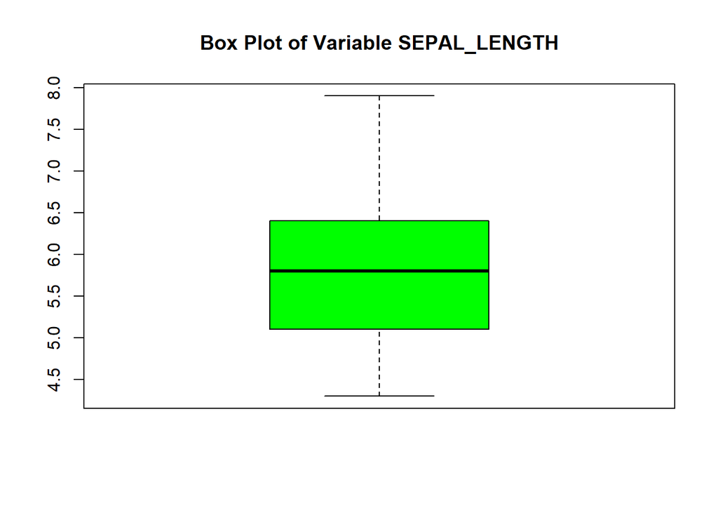

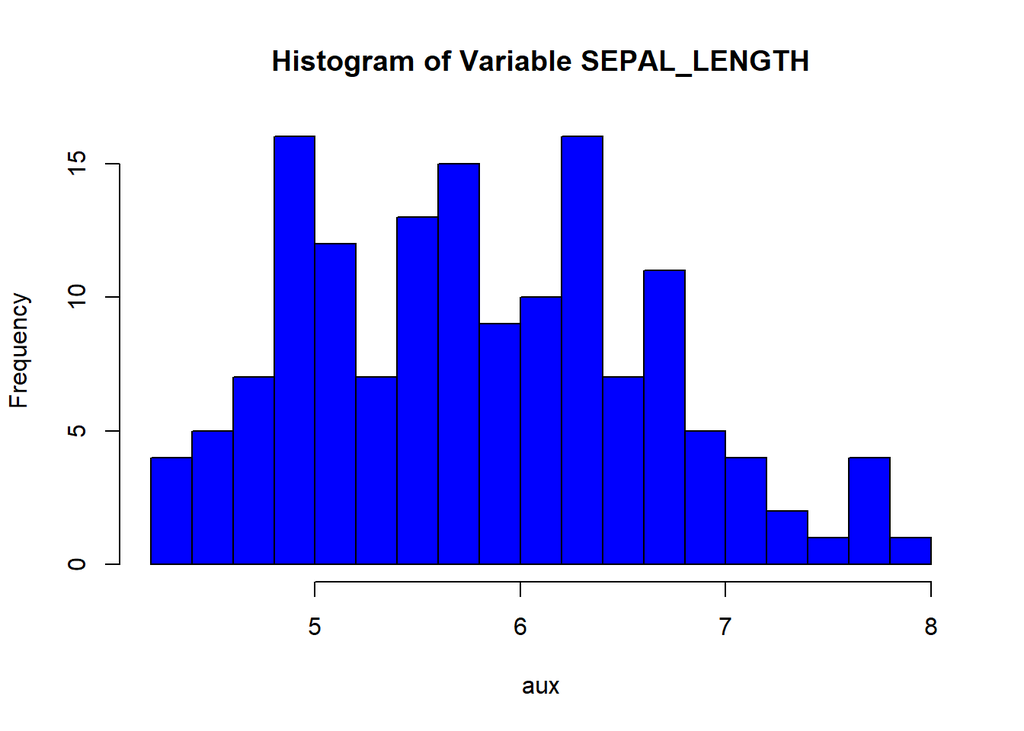

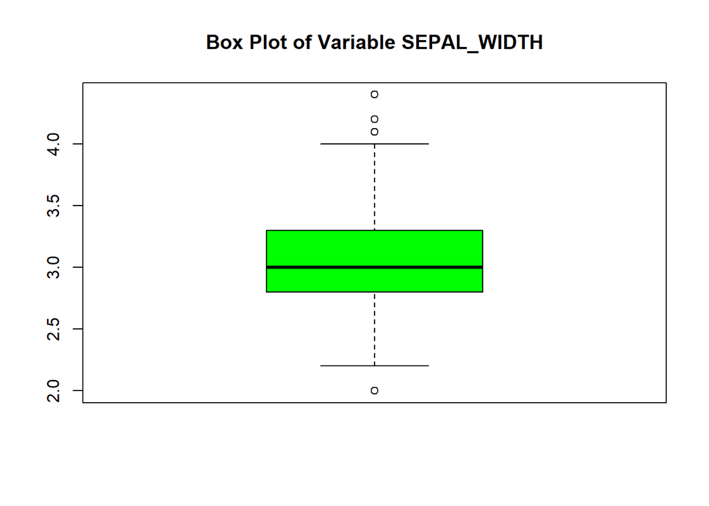

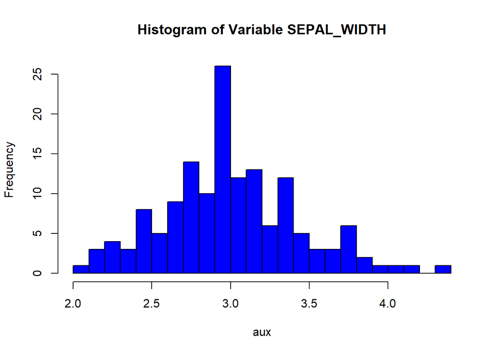

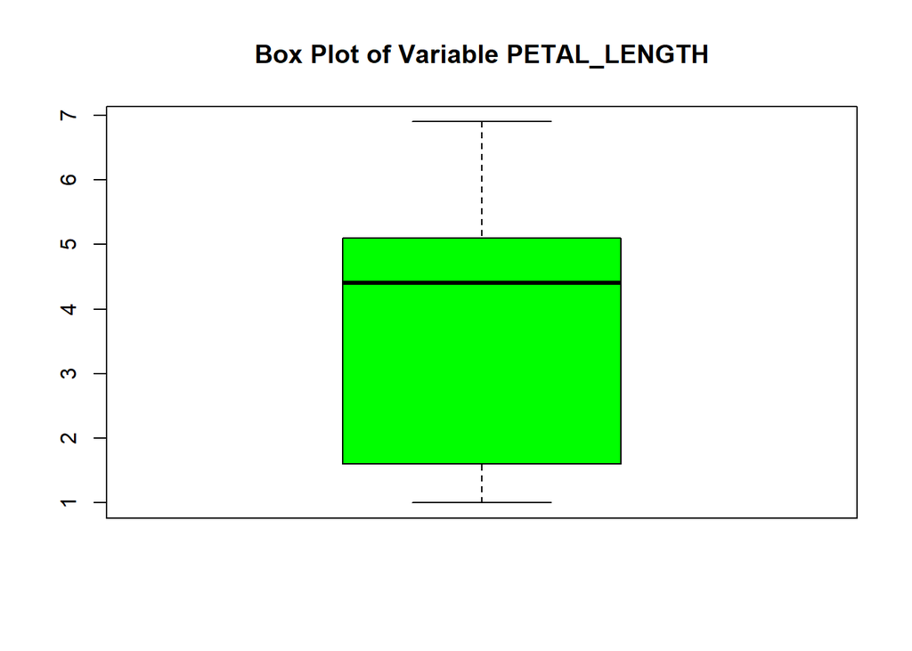

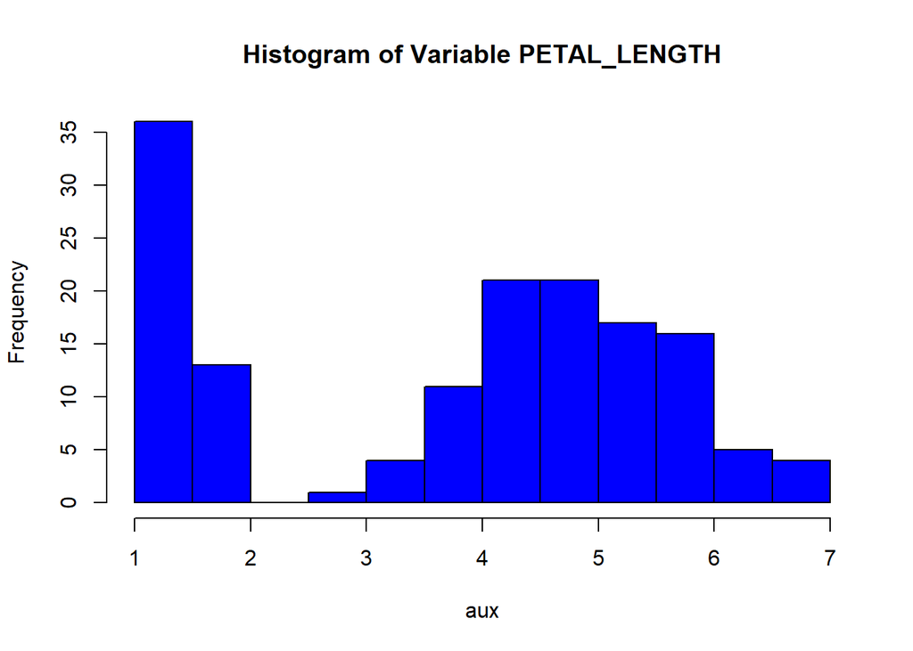

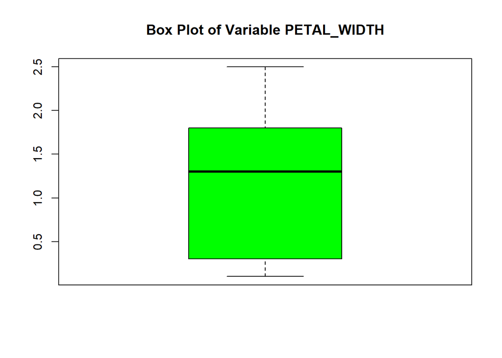

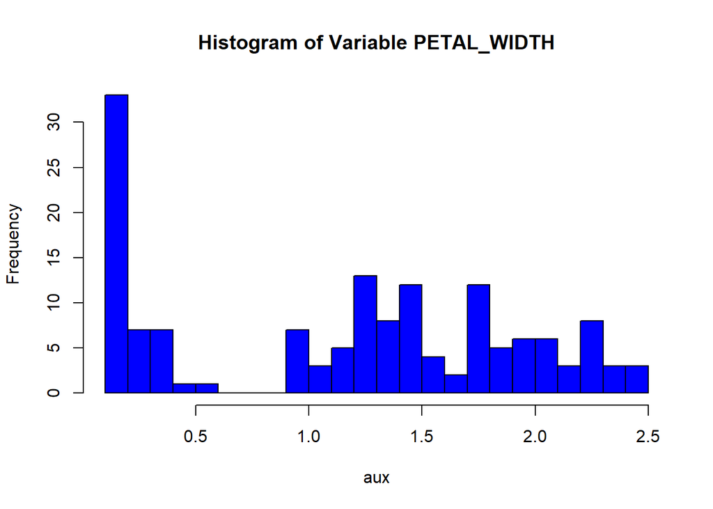

```r
# Plot Histograms

a = 1
for (aux in df_num){
  var_name = names(df_num)[a]
  boxplot(aux, col = 'green', main =paste("Box Plot of Variable", toupper(var_name)))
  hist(x = aux, nclass = 20, col= 'blue',main =paste("Histogram of Variable", toupper(var_name)))
  a = a + 1
}
```

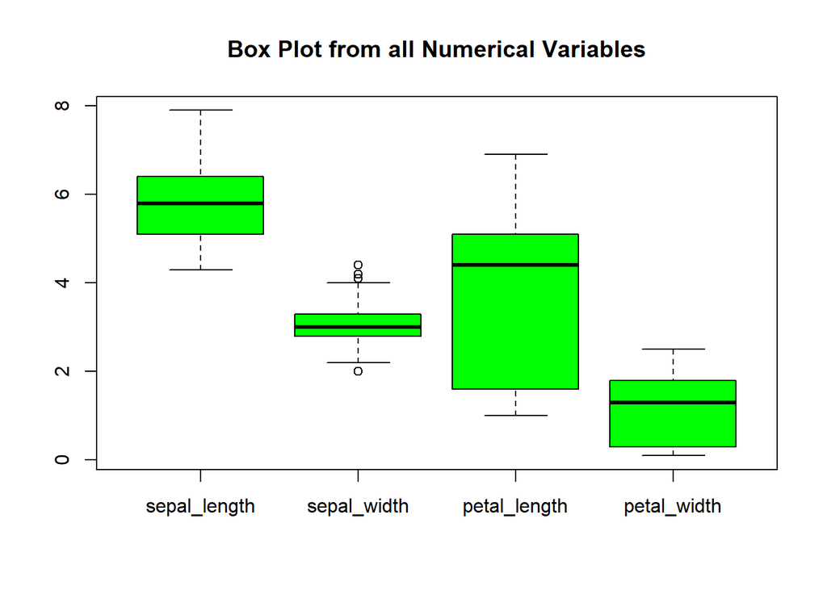

```r
boxplot(df_num, col = 'green', main ="Box Plot from all Numerical Variables")
```

#### **Graphical Analysis from Categorical Variables**

##### *Create frequency table*

```r
x = table(df[,5])
print(x)
```

```
##
##     Iris-setosa Iris-versicolor  Iris-virginica
##              49              50              50
```

##### *Create Bar Plot*

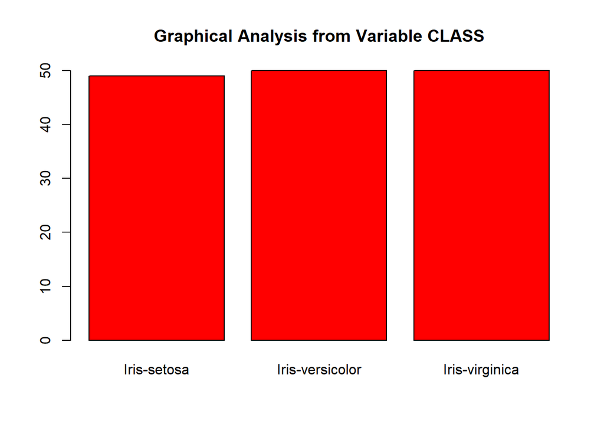

```r
barplot(x, main =paste("Graphical Analysis from Variable", toupper(names(df_cat))), col = 'red')
```

#### **Check for predictors normality**

##### *Visual normality test*

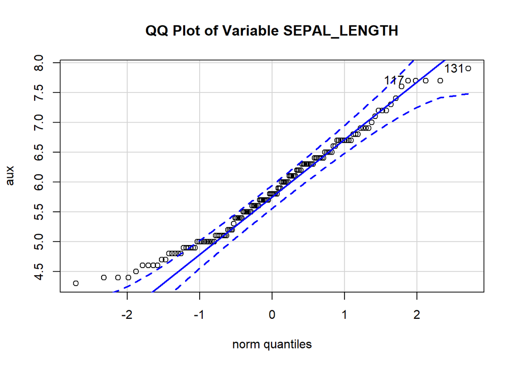

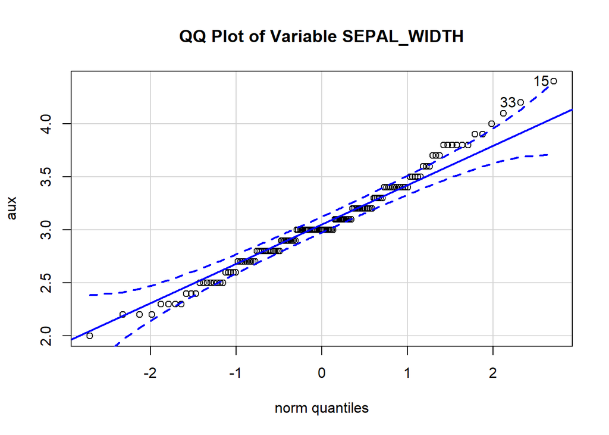

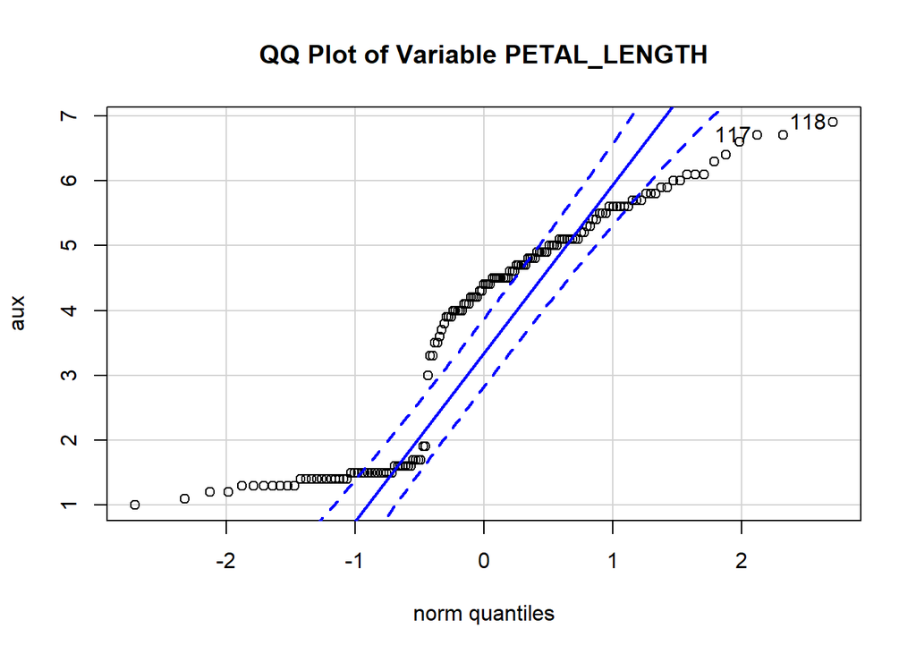

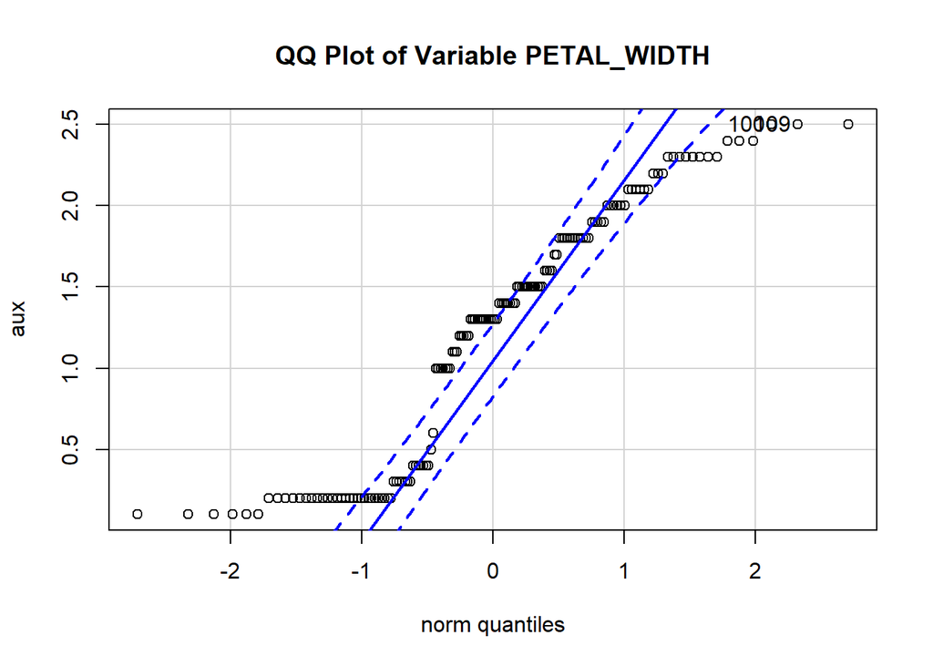

```r
# QQ Plot
a = 1
for (aux in df_num){
  var_name = names(df_num)[a]
  qqPlot(aux, main = paste("QQ Plot of Variable", toupper(var_name)))
  a = a + 1
}
```

##### *Numerical Normality Test*

```r
lapply(df_num, function(aux){
  shapiro.test(aux)
})
```

```
## $sepal_length
##
##  Shapiro-Wilk normality test
##
## data:  aux
## W = 0.97683, p-value = 0.01271
##
##
## $sepal_width
##
##  Shapiro-Wilk normality test
##
## data:  aux
## W = 0.98278, p-value = 0.05907
##
##
## $petal_length
##
##  Shapiro-Wilk normality test
##
## data:  aux
## W = 0.87744, p-value = 9.304e-10
##
##
## $petal_width
##
##  Shapiro-Wilk normality test
##
## data:  aux
## W = 0.90407, p-value = 2.458e-08
```

> If p-value is greater than 0.05 then we can consider that the variable has a Normal distribution**

#### **Perform Transformations**

##### *Create an auxiliar dataframe with only the non-normal variables*

```r
  df_num_nonnorm = df_num[,-2]
  head(df_num_nonnorm)
```

| sepal_length | petal_length | petal_width |
| --- | --- | --- |
| 4.9 | 1.4 | 0.2 |
| 4.7 | 1.3 | 0.2 |
| 4.6 | 1.5 | 0.2 |
| 5.0 | 1.4 | 0.2 |
| 5.4 | 1.7 | 0.4 |
| 4.6 | 1.4 | 0.3 |

##### *Check what is the best transformation to be performed*

```r
  lapply(df_num_nonnorm, function(aux){
    bestNormalize(aux)
  })
```

```
## $sepal_length
## Best Normalizing transformation with 149 Observations
##  Estimated Normality Statistics (Pearson P / df, lower => more normal):
##  - arcsinh(x): 1.4242
##  - Box-Cox: 1.4337
##  - Center+scale: 1.3027
##  - Exp(x): 3.3701
##  - Log_b(x+a): 1.4242
##  - orderNorm (ORQ): 1.5198
##  - sqrt(x + a): 1.3389
##  - Yeo-Johnson: 1.4337
## Estimation method: Out-of-sample via CV with 10 folds and 5 repeats
##
## Based off these, bestNormalize chose:
## center_scale(x) Transformation with 149 nonmissing obs.
##  Estimated statistics:
##  - mean (before standardization) = 5.848322
##  - sd (before standardization) = 0.8285941
##
## $petal_length
## Best Normalizing transformation with 149 Observations
##  Estimated Normality Statistics (Pearson P / df, lower => more normal):
##  - arcsinh(x): 4.3446
##  - Box-Cox: 2.9278
##  - Center+scale: 2.8924
##  - Exp(x): 3.8398
##  - Log_b(x+a): 4.3926
##  - orderNorm (ORQ): 1.1099
##  - sqrt(x + a): 3.4573
##  - Yeo-Johnson: 2.8105
## Estimation method: Out-of-sample via CV with 10 folds and 5 repeats
##
## Based off these, bestNormalize chose:
## orderNorm Transformation with 149 nonmissing obs and ties
##  - 43 unique values
##  - Original quantiles:
##   0%  25%  50%  75% 100%
##  1.0  1.6  4.4  5.1  6.9
##
## $petal_width
## Best Normalizing transformation with 149 Observations
##  Estimated Normality Statistics (Pearson P / df, lower => more normal):
##  - arcsinh(x): 2.879
##  - Box-Cox: 2.6638
##  - Center+scale: 2.3183
##  - Exp(x): 2.3583
##  - Log_b(x+a): 4.1613
##  - orderNorm (ORQ): 1.4722
##  - sqrt(x + a): 2.7926
##  - Yeo-Johnson: 2.3507
## Estimation method: Out-of-sample via CV with 10 folds and 5 repeats
##
## Based off these, bestNormalize chose:
## orderNorm Transformation with 149 nonmissing obs and ties
##  - 22 unique values
##  - Original quantiles:
##   0%  25%  50%  75% 100%
##  0.1  0.3  1.3  1.8  2.5
```

**Analysis:**

*For more details regarding Order Norm Quantile transformation see https://www.researchgate.net/publication/333808000_Ordered_quantile_normalization_a_semiparametric_transformation_built_for_the_cross-validation_era

#### **Performing Transformations**

##### *Creating a copy of the original dataframe for restore purpose.*

```r
df_original = df
```

##### *Apply Ordered Quantile Normalizing transformation to* petal_length* variable:*

```r
### INFORM THE VARIABLE TO BE TRANSFORMED HERE ###
var_to_be_transformed = df_num_nonnorm$petal_length


transformed_var = orderNorm(var_to_be_transformed)
transformed_var = predict(transformed_var, newdata = var_to_be_transformed)

shapiro.test(transformed_var)
```

```
##
##  Shapiro-Wilk normality test
##
## data:  transformed_var
## W = 0.99616, p-value = 0.967
```

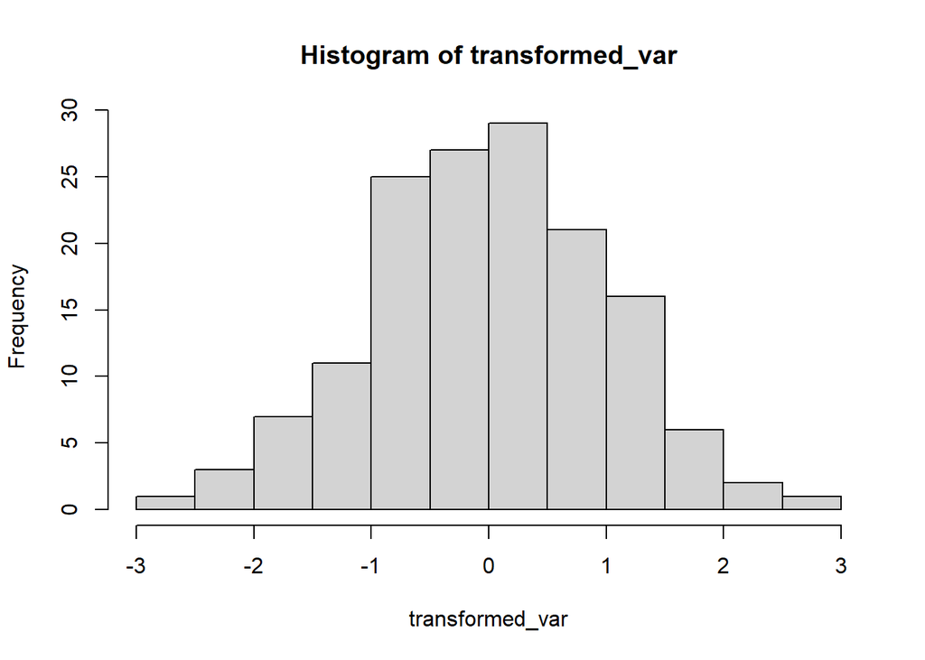

```r
hist(transformed_var)
```

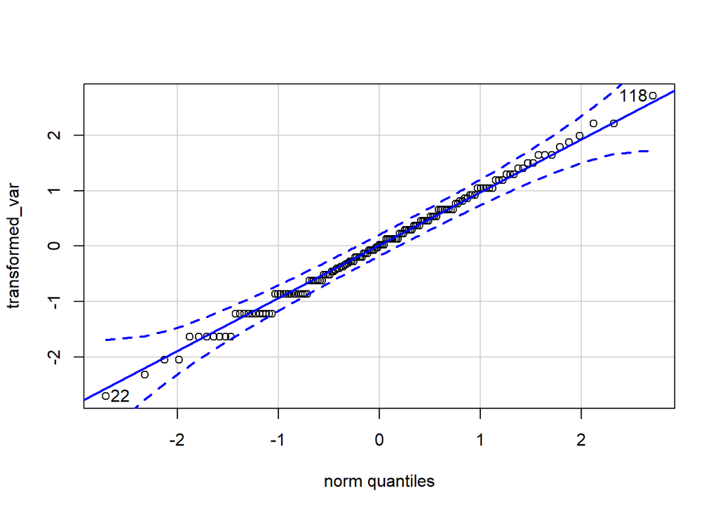

```
## [1]  22 118
```

```r
qqPlot(transformed_var)
```

**Analysis**

- After transformation *petal_length* variable is normally distributed.

##### *Adjust the dataset with the newly transformed variable:*

```r
# Create a new variable called petal_length_trans on the df dataframe

#### INSERT THE NEW VARIABLE NAME HERE AFTER df$ ####
df$petal_length_trans = transformed_var


# Erasing petal_length variable

#### INSERT THE OLD VARIABLE NAME HERE AFTER df$ ####
df$petal_length = NULL
```

##### *Apply Ordered Quantile Normalizing transformation to* petal_width* variable:*

```r
### INFORM THE VARIABLE TO BE TRANSFORMED HERE ###
var_to_be_transformed = df_num_nonnorm$petal_width


transformed_var = orderNorm(var_to_be_transformed)
transformed_var = predict(transformed_var, newdata = var_to_be_transformed)

shapiro.test(transformed_var)
```

```
##
##  Shapiro-Wilk normality test
##
## data:  transformed_var
## W = 0.97686, p-value = 0.01283
```

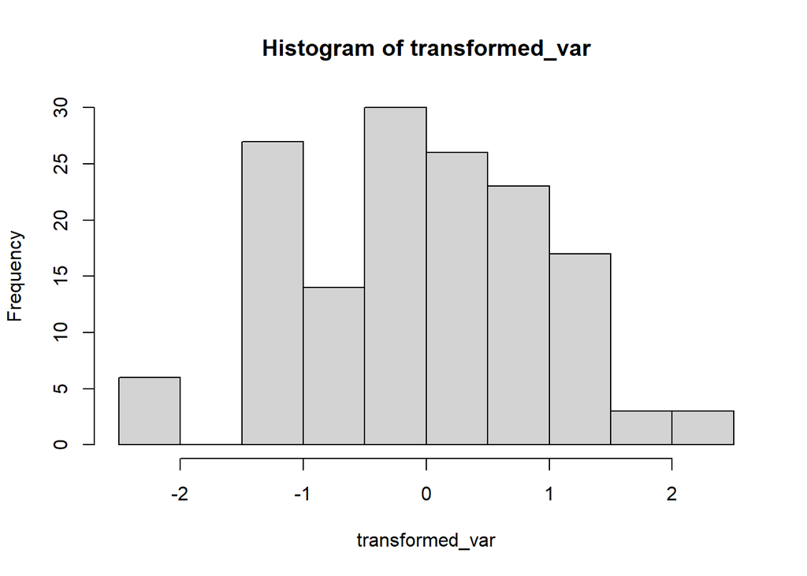

```r
hist(transformed_var)
```

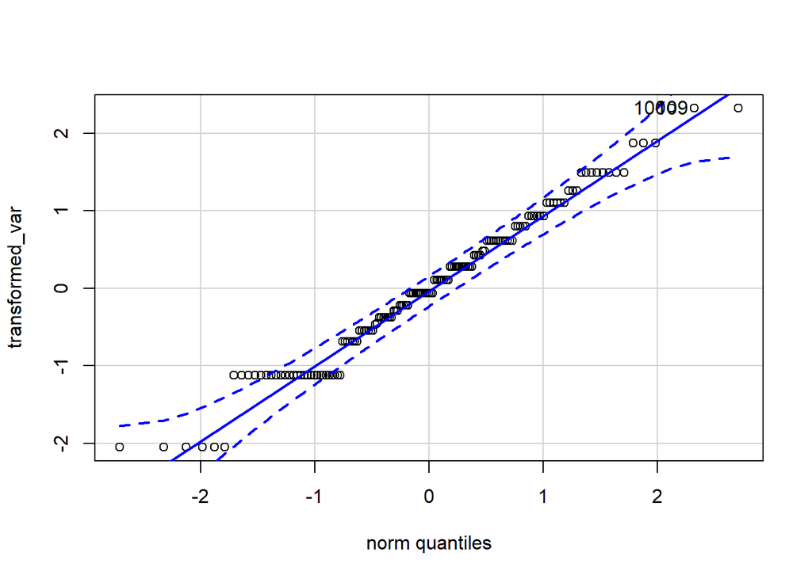

```
## [1] 100 109
```

```r
qqPlot(transformed_var)
```

**Analysis**

##### *Adjust the dataset with the newly transformed variable:*

```r
# Create a new variable called petal_length_trans on the df dataframe

#### INSERT THE NEW VARIABLE NAME HERE AFTER df$ ####
df$petal_width_trans = transformed_var


# Erasing petal_length variable

#### INSERT THE OLD VARIABLE NAME HERE AFTER df$ ####
df$petal_width = NULL
```

##### *Clean unused variables*

```r
rm("df_cat", "df_num", "df_num_nonnorm", "a", "x", "aux", "transformed_var", "var_to_be_transformed",
   "var_name")
```

##### *Create different dataframes for predictor variables and response variable:*

```r
df_predictors = df[,-3]
df_response = df[,3]
```

#### **Correlation Analysis**

##### *Study the correlations between predictors*

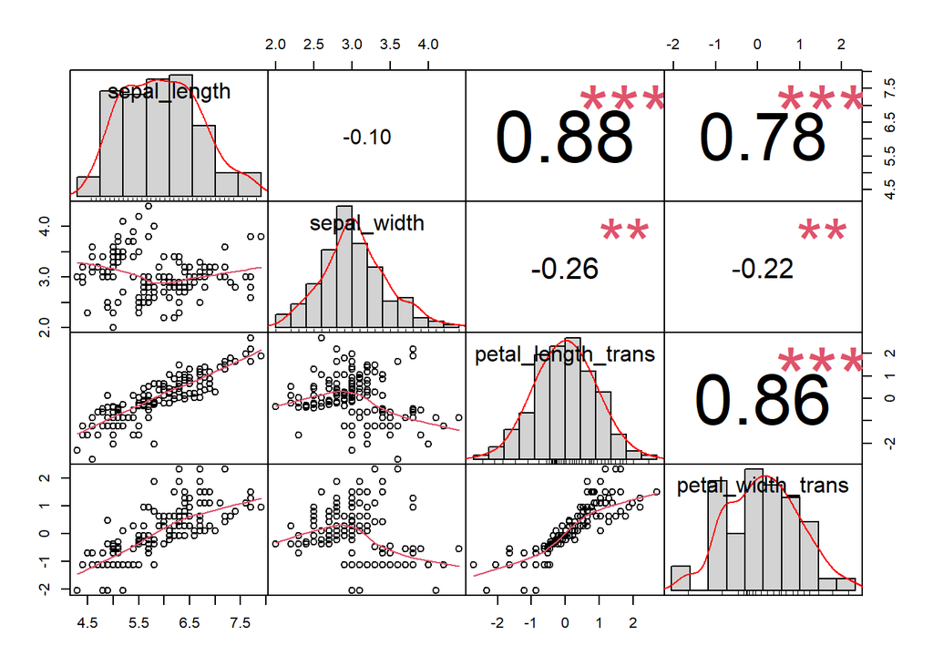

```r
chart.Correlation(R = df_predictors, histogram = TRUE, method = "pearson")
```

**Analysis**

> Os métodos de Spearman e Pearson somente funcionam quando há relação linear entre as variáveis.  
> Para relações não lineares faz-se necessário o uso de outros métodos, tal como DISTANCE CORRELATION.  
> Pacote R: energy  
> Pacote Python: Scipy.spatial.distance.correlation  
> https://en.wikipedia.org/wiki/Distance_correlation

> The following points are the accepted guidelines for interpreting the correlation coefficient:  
> 1. 0 indicates no linear relationship.  
> 2. +1 indicates a perfect positive linear relationship – as one variable increases in its values, the other variable also increases in its values through an exact linear rule.  
> 3. −1 indicates a perfect negative linear relationship – as one variable increases in its values, the other variable decreases in its values through an exact linear rule.  
> 4. Values between 0 and 0.3 (0 and −0.3) indicate a weak positive (negative) linear relationship through a shaky linear rule.  
> 5. Values between 0.3 and 0.7 (0.3 and −0.7) indicate a moderate positive (negative) linear relationship through a fuzzy-firm linear rule.  
> 6. Values between 0.7 and 1.0 (−0.7 and −1.0) indicate a strong positive (negative) linear relationship through a firm linear rule.  
> 7. The value of r2, called the coefficient of determination, and denoted R2 is typically interpreted as ‘the percent of variation in one variable explained by the other variable,’ or ‘the percent of variation shared between the two variables.

##### *Study the correlations between predictors and response variable*

```r
for (aux in 1:149){
  if(df_response$class[aux] == "Iris-setosa")
    df_response$class[aux] = 0
  else if(df_response$class[aux] == "Iris-versicolor")
    df_response$class[aux] = 1
  else if(df_response$class[aux] == "Iris-virginica")
    df_response$class[aux] = 2
}

df_response$class = as.factor(df_response$class)
df_aux = cbind(df_predictors, df_response)
```

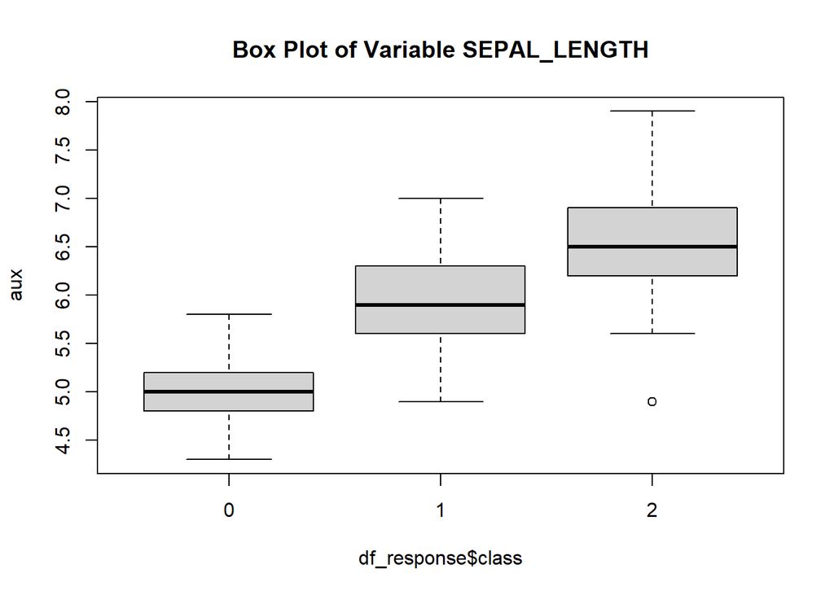

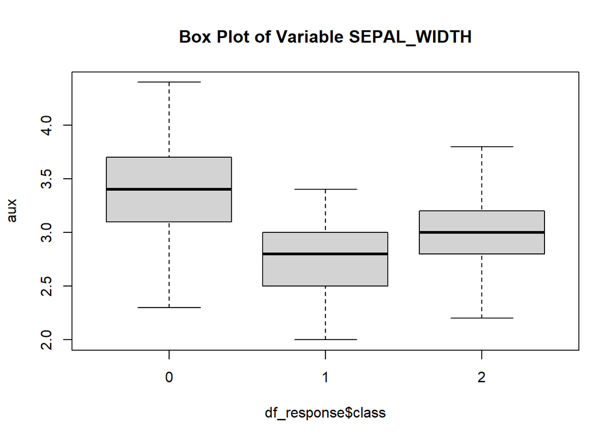

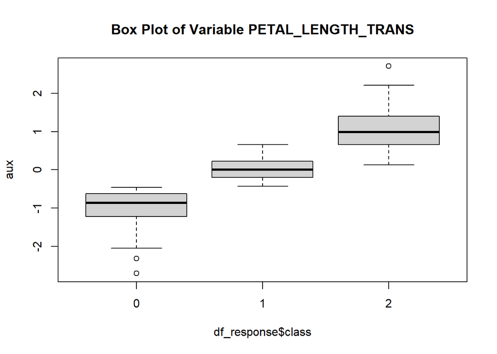

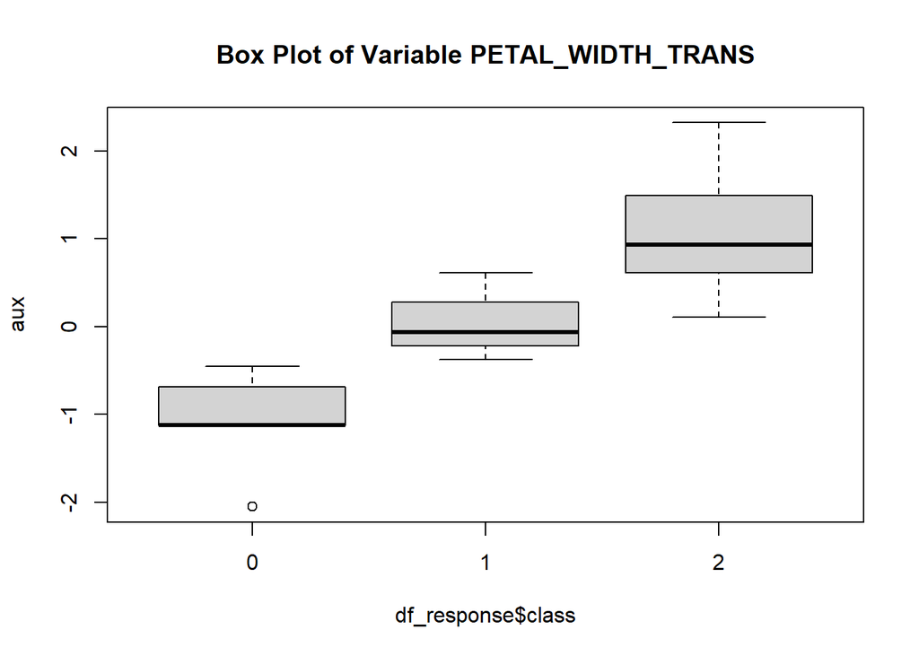

```r
# Box Plot
a = 1
for (aux in df_predictors){
  var_name = names(df_predictors)[a]
  boxplot(aux ~ df_response$class, main = paste("Box Plot of Variable", toupper(var_name)))
  a = a + 1
}
```

##### *Kruskal-Wallis Rank Sum Test*

```r
lapply(df_predictors, function(var){
  kruskal.test(var ~ df_response$class)
})
```

```
## $sepal_length
##
##  Kruskal-Wallis rank sum test
##
## data:  var by df_response$class
## Kruskal-Wallis chi-squared = 95.969, df = 2, p-value < 2.2e-16
##
##
## $sepal_width
##
##  Kruskal-Wallis rank sum test
##
## data:  var by df_response$class
## Kruskal-Wallis chi-squared = 61.217, df = 2, p-value = 5.093e-14
##
##
## $petal_length_trans
##
##  Kruskal-Wallis rank sum test
##
## data:  var by df_response$class
## Kruskal-Wallis chi-squared = 129.48, df = 2, p-value < 2.2e-16
##
##
## $petal_width_trans
##
##  Kruskal-Wallis rank sum test
##
## data:  var by df_response$class
## Kruskal-Wallis chi-squared = 130.09, df = 2, p-value < 2.2e-16
```

##### *Variables importance based on ROC*

```r
# Categorical variable must be 0, 1 and 2
rocValues = filterVarImp(df_aux[,-5], df_aux$class)
head(rocValues)
```

|  | X0 | X1 | X2 |
| --- | --- | --- | --- |
| sepal_length | 0.9846939 | 0.9326531 | 0.9846939 |
| sepal_width | 0.9206122 | 0.9206122 | 0.8271429 |
| petal_length_trans | 1.0000000 | 1.0000000 | 1.0000000 |
| petal_width_trans | 1.0000000 | 1.0000000 | 1.0000000 |

##### *Variables importance based on Relief algorithm*

```r
relief = attrEval(formula = class ~ ., data = df_aux, estimator = 'ReliefFequalK', ReliefIterations = 50)
head(relief)
```

```
##       sepal_length        sepal_width petal_length_trans  petal_width_trans
##         0.28238739         0.07458474         0.61743945         0.61528330
```

##### *Variables importance based on method*

```r
set.seed(791)
rfImp = randomForest(class ~ ., data = df_aux, ntree = 2000, importance = TRUE)
head(varImp(rfImp))
```

|  | 0 | 1 | 2 |
| --- | --- | --- | --- |
| sepal_length | 13.83027 | 16.666177 | 16.365485 |
| sepal_width | 10.06730 | 3.535238 | 8.361503 |
| petal_length_trans | 46.79018 | 69.160602 | 56.510104 |
| petal_width_trans | 42.00395 | 60.890835 | 58.690498 |

##### *Scatterplot Matrix*

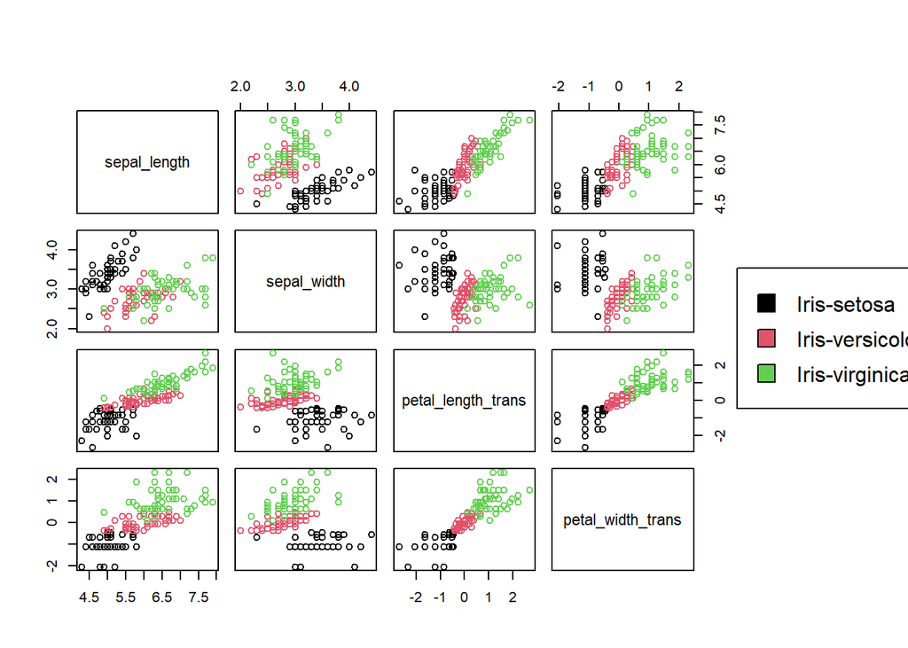

```r
pairs(df_aux[,1:4],col=df_aux[,5],oma=c(4,4,6,12))
par(xpd=TRUE)
legend(0.85,0.6, as.vector(unique(df$class)),fill=c(1,2,3))
```

```r
write_csv(x = df_aux, file = "./data/processed/iris.csv")
```